# Predykcja poziomu dochodów z użyciem modeli klasyfikacyjnych

Autor

Patrycja Mazur

# 1 Cel projektu

Celem projektu jest zbudowanie **modelu klasyfikacyjnego**, który na podstawie cech przewidzi, czy dana osoba zarabia **ponad 50 tysięcy** dolarów rocznie.

Model ma pomóc w identyfikacji czynników wpływających na wysokie dochody oraz umożliwić skuteczną klasyfikację przyszłych obserwacji.

Wykorzystane zostaną metody uczenia maszynowego, takie jak **regresja logistyczna**, **drzewo decyzyjne**, **las losowy**, **naiwny klasyfikator bayesowski**, algorytm **K najbliższych sąsaidów** oraz **XGBoost**, a także techniki przetwarzania danych i strojenia hiperparametrów.

# 2 Zbiór danych

Pierwsze przykładowe 100 obserwacji:

|  | age | workclass | fnlwgt | education | education.num | marital.status | occupation | relationship | race | sex | capital.gain | capital.loss | hours.per.week | native.country | income |
| --- | --- | --- | --- | --- | --- | --- | --- | --- | --- | --- | --- | --- | --- | --- | --- |
| 1 | 90 | ? | 77053 | HS-grad | 9 | Widowed | ? | Not-in-family | White | Female | 0 | 4356 | 40 | United-States | &lt;=50K |
| 2 | 82 | Private | 132870 | HS-grad | 9 | Widowed | Exec-managerial | Not-in-family | White | Female | 0 | 4356 | 18 | United-States | &lt;=50K |
| 3 | 66 | ? | 186061 | Some-college | 10 | Widowed | ? | Unmarried | Black | Female | 0 | 4356 | 40 | United-States | &lt;=50K |
| 4 | 54 | Private | 140359 | 7th-8th | 4 | Divorced | Machine-op-inspct | Unmarried | White | Female | 0 | 3900 | 40 | United-States | &lt;=50K |
| 5 | 41 | Private | 264663 | Some-college | 10 | Separated | Prof-specialty | Own-child | White | Female | 0 | 3900 | 40 | United-States | &lt;=50K |
| 6 | 34 | Private | 216864 | HS-grad | 9 | Divorced | Other-service | Unmarried | White | Female | 0 | 3770 | 45 | United-States | &lt;=50K |
| 7 | 38 | Private | 150601 | 10th | 6 | Separated | Adm-clerical | Unmarried | White | Male | 0 | 3770 | 40 | United-States | &lt;=50K |
| 8 | 74 | State-gov | 88638 | Doctorate | 16 | Never-married | Prof-specialty | Other-relative | White | Female | 0 | 3683 | 20 | United-States | &gt;50K |
| 9 | 68 | Federal-gov | 422013 | HS-grad | 9 | Divorced | Prof-specialty | Not-in-family | White | Female | 0 | 3683 | 40 | United-States | &lt;=50K |
| 10 | 41 | Private | 70037 | Some-college | 10 | Never-married | Craft-repair | Unmarried | White | Male | 0 | 3004 | 60 | ? | &gt;50K |

[output cut: 90 more lines]

## 2.1 Opis zbioru

Źródło: https://www.kaggle.com/datasets/uciml/adult-census-income/data

Zbiór danych **Adult Census Income** pochodzi z badania amerykańskiego spisu powszechnego i zawiera **32 561** obserwacji. Dane obejmują cechy m.in. takie jak wiek, wykształcenie, stan cywilny, zawód, liczba przepracowanych godzin tygodniowo oraz kraj pochodzenia. Celem analizy jest przewidywanie, czy dochód osoby **przekracza próg 50 tysięcy** dolarów rocznie (zmienna binarna).

Zbiór zawiera **15 zmiennych**:

Opis zmiennych

| Zmienna | Opis | Typ | Zakres | Uwagi |
| --- | --- | --- | --- | --- |
| age | Wiek | numeric | 17-90 | - |
| workclass | Typ zatrudnienia | factor | Federal-gov, Local-gov, Never-worked, Private, Self-emp-inc, Self-emp-not-inc, State-gov, Without-pay | '?' - 1836; 8 poziomów |
| fnlwgt | Waga obserwacji nadana przez amerykańskie Biuro Spisu Ludności (U.S. Census Bureau) | numeric | 12285 – 1484705 | - |
| education | Poziom wykształcenia | factor | 10th, 11th, 12th, 1st-4th, 5th-6th, 7th-8th, 9th, Assoc-acdm, Assoc-voc, Bachelors, Doctorate, HS-grad, Masters, Preschool, Prof-school, Some-college | 16 poziomów |
| education.num | Liczbowa wersja wykształcenia | numeric | 1 - 16 | - |
| marital.status | Stan cywilny | factor | Divorced, Married-AF-spouse, Married-civ-spouse, Married-spouse-absent, Never-married, Separated, Widowed | 7 poziomów |
| occupation | Zawód | factor | Adm-clerical, Armed-Forces, Craft-repair, Exec-managerial, Farming-fishing, Handlers-cleaners, Machine-op-inspct, Other-service, Priv-house-serv, Prof-specialty, Protective-serv, Sales, Tech-support, … | '?' - 1843; 14 poziomów |
| relationship | Relacje | factor | Husband, Not-in-family, Other-relative, Own-child, Unmarried, Wife | 6 poziomów |
| race | Rasa/pochodzenie etniczne | factor | Amer-Indian-Eskimo, Asian-Pac-Islander, Black, Other, White | 5 poziomów |
| sex | Płeć | factor | Female, Male | 2 poziomy |
| capital.gain | Dochód kapitałowy | numeric | 0-99999 | - |
| capital.loss | Straty kapitałowe | numeric | 0-4356 | - |
| hours.per.week | Liczba przepracowanych godzin tygodniowo | numeric | 1-99 | - |
| native.country | Kraj pochodzenia | factor | Cambodia, Canada, China, Columbia, Cua, Dominican-Republic, Ecuador, El-Salvador, England, France, Germany, Greece, Guatemala, Haiti, Holand-Netherlands, Honduras, Hong, Hungary, India, Iran, Ireland,… | '?'- 583; 41 poziomów |
| income | Dochód; Zmienna docelowa (target) – czy dana osoba zarabia mniej czy więcej niż $50K rocznie | factor | <=50K – do 50 000 USD, >50K – powyżej 50 000 USD rocznie | 2 poziomy |

## 2.2 Braki danych

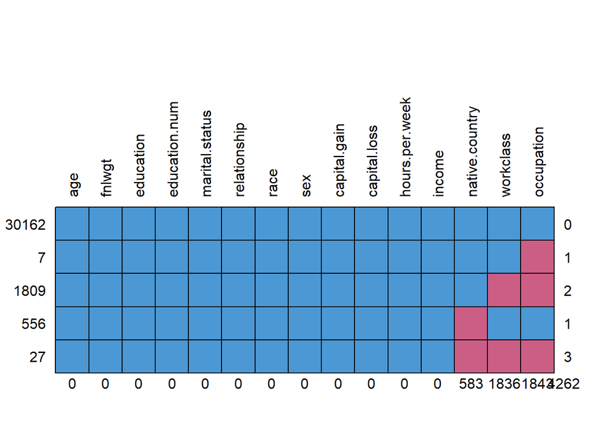

W zbiorze danych występuje **30 162** wiersze **bez braków danych**. Jest również:

- **7** wierszy, które mają braki danych tylko w zmiennej *`occupation`*, a pozostałe zmienne mają uzupełnione wartości.
- **1809** wierszy gdzie występuje brak danych w zmiennych *`workclass`* i *`occupation`*, a pozostałe wartości są uzupełnione.
- **556** wierszy zawierających brakującą wartość tylko dla zmiennej *`native.country`*.
- **27** wierszy gdzie są braki danych jednocześnie w *`native.country`*, *`workclass`* i *`occupation`*.

Około **7,4%** całego zbioru danych zawiera wartości brakujące. Usuniemy jedynie 27 wierszy, które posiadają braki we wszystkich trzech kolumnach jednocześnie. Pozostałe brakujące wartości zostaną zastąpione wartością „Unknown”. Dzięki temu unikniemy usuwania dużej liczby obserwacji, w tym także tych nietypowych np. nietypowego zawodu.

Po usunięciu wspomnianych 27 rekordów, zbiór danych liczy teraz **32 534** obserwacje.

## 2.3 Analiza zbioru danych

Zanim przystąpimy do budowy modeli, przyjrzymy się bliżej danym. Sprawdzimy m.in. jak wygląda rozkład dochodów oraz jakie zależności występują między zmiennymi. Taka analiza pozwoli nam lepiej zrozumieć dane i przygotować je do dalszych etapów pracy.

### 2.3.1 Procentowy rozkład zmiennej **income**

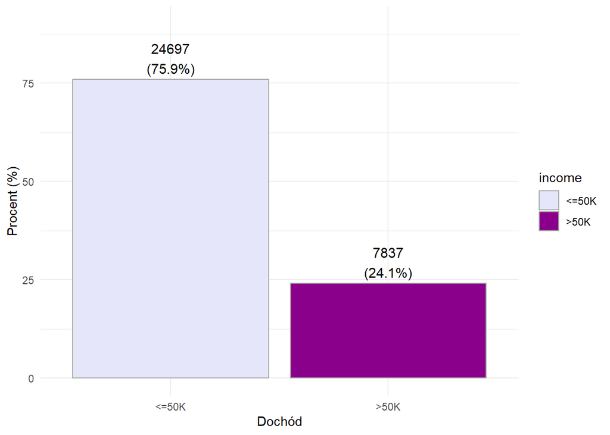

Na podstawie wykresu możemy zauważyć, że zmienna docelowa **`income`** jest **niezbalansowana**. Większość obserwacji – **75,9%** – dotyczy dochodów równych lub poniżej $50K **(<=50K)**, natomiast **24,1%** stanowią dochody powyżej $50K **(>50K)**. Taka dysproporcja klas może mieć istotny wpływ na skuteczność modeli klasyfikacyjnych i wymaga odpowiednich technik balansowania danych, takich jak np. *oversampling*.

### 2.3.2 Zależność dochodu od wieku

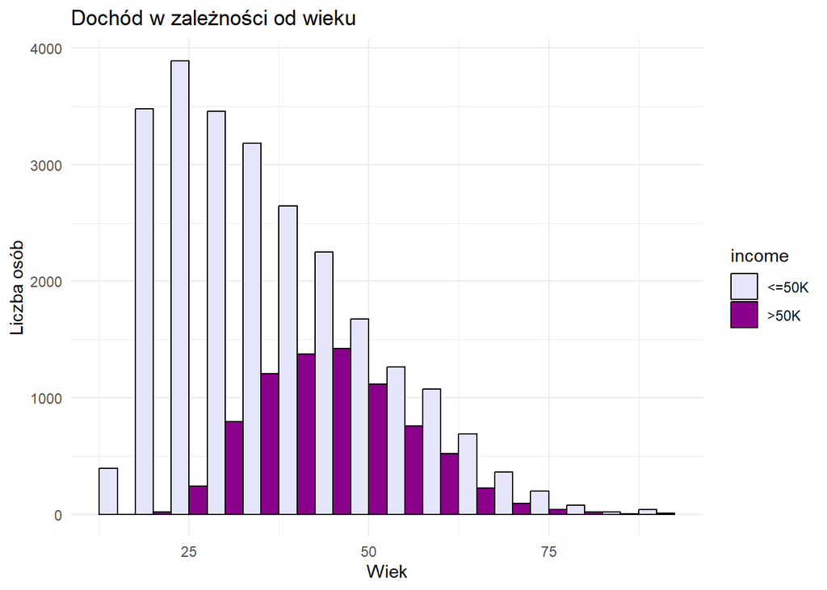

Młodsze osoby najczęściej zarabiają do 50 tysięcy dolarów rocznie. Wraz z wiekiem, szczególnie w przedziale 25–50 lat, widoczny jest wzrost zarobków, a coraz więcej osób przekracza próg 50 tysięcy dolarów.

### 2.3.3 Hours per week

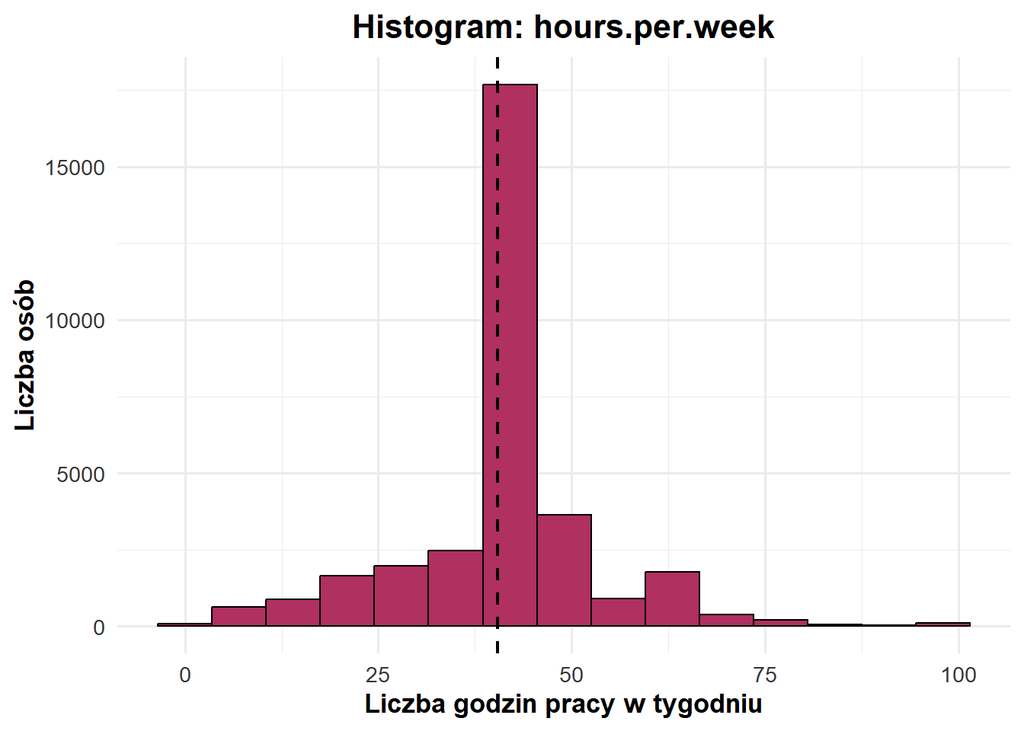

Rozkład godzin pracy jest dość symetryczny, bez dużych odchyleń w jedną stronę.

| zmienna | średnia | mediana | min | max | odch. standardowe | Q1 | Q3 |
| --- | --- | --- | --- | --- | --- | --- | --- |
| hours.per.week | 40.44 | 40 | 1 | 99 | 12.34 | 40 | 45 |

**Mediana** i **średnia** liczba godzin pracy wynosi około 40. Większość osób realizuje standardowy wymiar pracy (około 40 godz./tydz), ale istnieją też skrajne przypadki z mniejszą lub znacząco większą liczbą godzin pracy.

### 2.3.4 Płeć a dochód

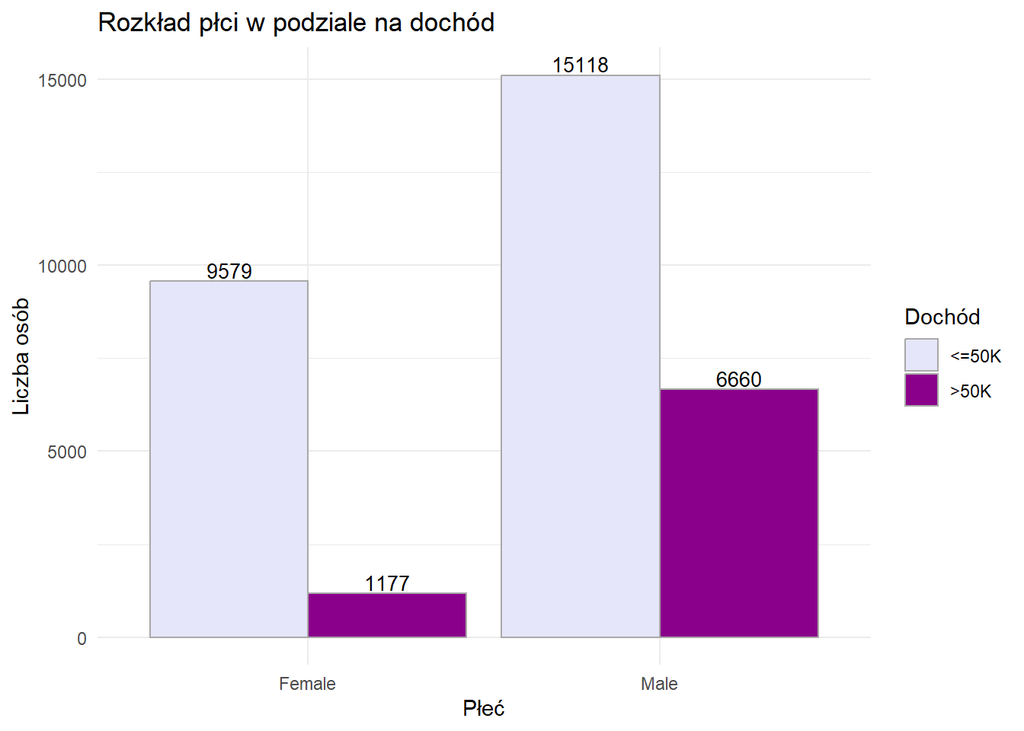

|  | <=50K | >50K |
| --- | --- | --- |
| Female | 9579 | 1177 |
| Male | 15118 | 6660 |

Wśród **kobiet** zdecydowana większość (**9579**) zarabia nie więcej niż 50K (<=50K), a tylko **1177** osiąga wyższy dochód (>50). U **mężczyzn** również przeważają zarobki do 50K (**15 118 osób**), ale aż **6660** osiąga dochód powyżej tej granicy. Mężczyźni są liczniejsi w obu grupach, szczególnie w tej lepiej zarabiającej. Procent kobiet zarabiających powyżej 50 tys. w stosunku do wszytskich kobiet jest mniejszy niż procent mężczyzn zarabiających powyżej 50 tys. w stosunku do wszystkich mężczyzn. Dane sugerują, że kobiety rzadziej należą do grupy z wyższym dochodem.

### 2.3.5 Typ zatrudnienia

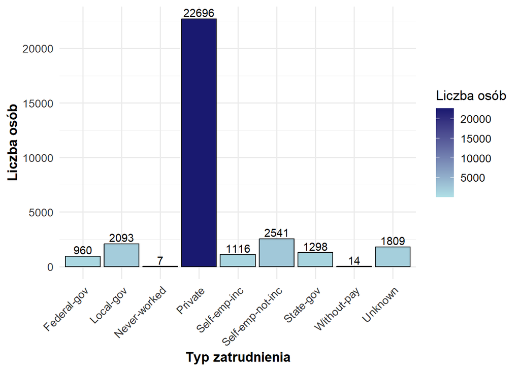

| Typ zatrudnienia | Liczba osób |
| --- | --- |
| Federal-gov | 960 |
| Local-gov | 2093 |
| Never-worked | 7 |
| Private | 22696 |
| Self-emp-inc | 1116 |
| Self-emp-not-inc | 2541 |
| State-gov | 1298 |
| Without-pay | 14 |
| Unknown | 1809 |

W zbiorze dominują osoby zatrudnione w sektorze prywatnym (**Private** - 22 696 osób), co stanowi zdecydowaną większość. Najmniej liczną grupą są osoby nigdy niepracujące (**Never-worked** - 7 osób) oraz bez wynagrodzenia (**Without-pay** 14) . Nieznany tryb zatrudnienia (*Unknown*) ma 1809 osób.

### 2.3.6 Korelacja zmiennych liczbowych

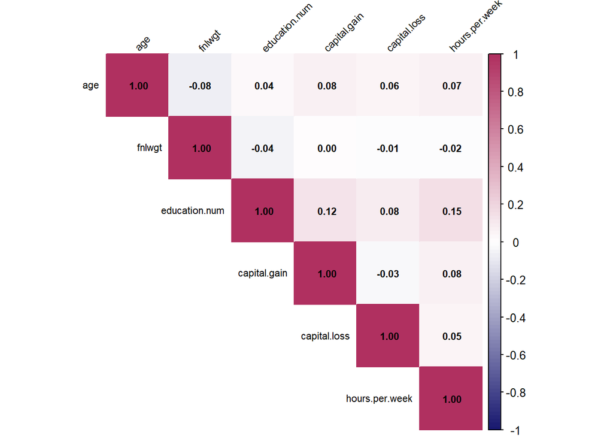

**Współczynniki korelacji** między zmiennymi są niskie, co wskazuje na słabe powiązania liniowe między nimi. Najwyższa dodatnia korelacja występuje między `education.num` a `hours.per.week` (około **0.15**), sugerując, że osoby z wyższym wykształceniem nieco częściej pracują więcej godzin. Jednak wszystkie korelacje są bardzo słabe lub niemal zerowe.

### 2.3.7 Rozkłady zmiennych numerycznych

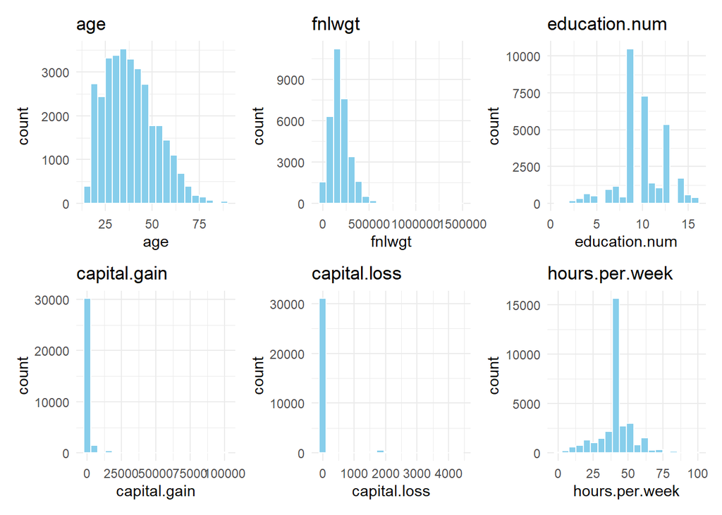

Rozkład zmiennej `age` jest zbliżony do normalnego, rozkład `fnlwgt` jest prawostronnie asymetryczny. `education.num` odzwierciedla różne poziomy wyksztacenia. Zmienne `capital.gain` oraz `capital.loss` wyróżniają się dużą asymetrią, większość wartości to 0 lub małe liczby.

### 2.3.8 capital.gain

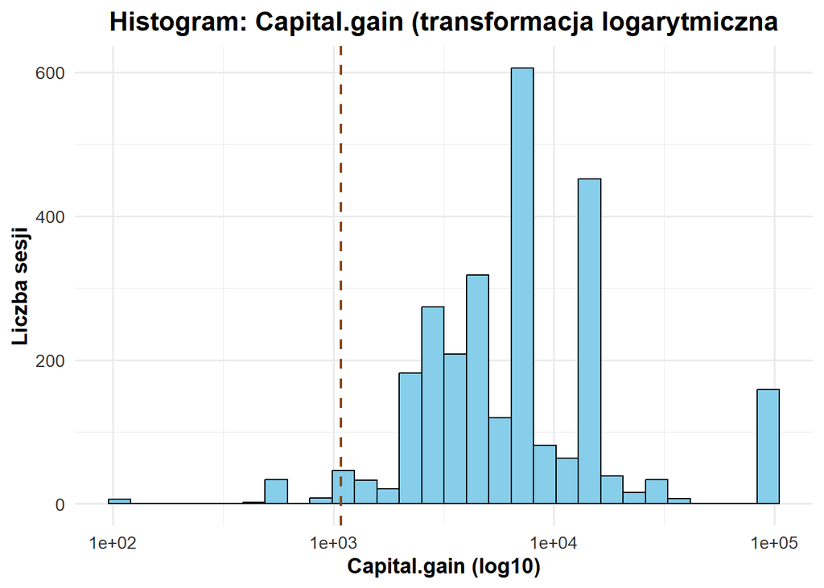

| zmienna | średnia | mediana | min | max | odch. standardowe | Q1 | Q3 |
| --- | --- | --- | --- | --- | --- | --- | --- |
| capital.gain | 1078.08 | 0 | 0 | 99999 | 7388.18 | 0 | 0 |

### 2.3.9 capital.loss

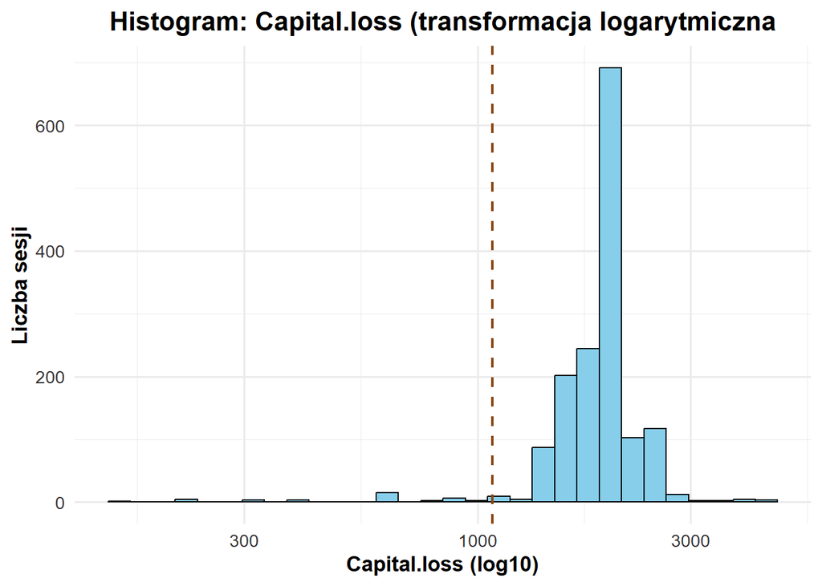

| zmienna | średnia | mediana | min | max | odch. standardowe | Q1 | Q3 |
| --- | --- | --- | --- | --- | --- | --- | --- |
| capital.loss | 87.27 | 0 | 0 | 4356 | 402.93 | 0 | 0 |

Ponownie zarówno **mediana**, jak i **oba kwartyle** (Q1 i Q3) wynoszą **0**, co oznacza, że co najmniej 75% obserwacji ma `capital.loss` równe 0. Tutaj podobnie pojawiają się nieliczne wysokie wartości.

# 3 Metoda analizy

## 3.1 Regresja logistyczna (Logistic Regression)

*Regresja logistyczna* to algorytm klasyfikacji, służący do przewidywania prawdopodobieństwa przynależności obserwacji do jednej z dwóch klas (sukces i porażka). Model opiera się na funkcji logistycznej (sigmoidzie), która przekształca liniową kombinację cech (predyktorów $X$) w wartość z zakresu od 0 do 1, interpretowaną jako prawdopodobieństwo sukcesu.

Ogólna postać modelu:

$$Y \sim B(1,p)$$

$$p(X) = E(Y|X) = \frac{exp(\beta X)}{1 + exp(\beta X)}$$

gdzie $B(1,p)$ jest rozkładem dwumianowym o prawdopodobieństwie sukcesu $p$, a $\beta X$ oznacza kombinację liniową parametrów modelu i wartości zmiennych niezależnych, przyjmując, że $x_0 = 1$.

## 3.2 Drzewo decyzyjne (Decision Tree)

*Drzewa decyzyjne* stosowane są szczególnie wtedy, gdy funkcyjna postać związku pomiędzy predyktorami a zmienną wynikową jest nieznana lub ciężka do ustalenia. Każde drzewo decyzyjne składa się z korzenia (ang. *root*), węzłów (ang. *nodes*) i liści (ang. *leaves*). Korzeń to początkowy węzeł drzewa, z którego poprzez podziały (ang. *splits*) powstają kolejne węzły potomne. Końcowe węzły, które nie podlegają podziałom nazywamy liśćmi, a linie łączące węzły nazywamy gałęziami (ang. *branches*).

Drzewa decyzyjne można stosować zarówno do zadań klasyfikacyjnych, jak i regresyjnych. W przypadku klasyfikacji, każdy liść drzewa wskazuje, do której klasy należy dana obserwacja - czyli która klasa jest najbardziej prawdopodobna po przejściu przez kolejne podziały. W przypadku regresji, liście zawieracją zazwyczaj średnią wartość zmiennej wynikowej dla obserwacji, które tam trafiły.

Do zalet drzew decyzyjnych należy przede wszystkim łatwość interpretacji, niewielkie wymagania dotyczące przygotowania danych oraz możliwość pracy zarówno na zmiennych jakościowych, jak i ilościowych.

## 3.3 Las losowy (Random Forest)

*Las losowy* to metoda polegająca na losowym wyborze dla każdego drzewa wchodzącego w skład lasu $m$ predyktorów spośród $p$ dostępnych, a następnie budowaniu drzew z wykorzystaniem tylko tych predyktorów. Dzięki temu za każdym razem drzewo jest budowane w oparciu o nowy zestaw cech (najczęściej przyjmujemy $m = \sqrt{p}$ ).

Dzięki uśrednianiu wyników poszczególnych drzew model ten uzyskuje wysoką stabilość i dokładność. Las losowy skutecznie zmniejsza ryzyko przeuczenia i jest jedną z najpopularniejszych metod stosowanych w zadaniach klasyfikacyjnych.

## 3.4 Naiwny klasyfikator Bayesa (Naive Bayes)

Jest to dość prosty klasyfikator probabilistyczny bazujący na twierdzeniu Bayesa. *Naiwne klasyfikatory bayesowskie* są oparte na założeniu o wzajemnej niezależności predyktorów (zmiennych niezależnych). Założenie to często nie jest spełnone i stąd nazwa przymiotnik “naiwny”.

Mimo swojej prostoty, często daje zaskakująco dobre wyniki w klasyfikacji, szczególnie przy dużych zbiorach danych i niezrównoważonych klasach.

## 3.5 XGBoost (Extreme Gradient Boosting)

**XGBoost (Extreme Gradient Boosting)** to wydajna i popularna metoda uczenia maszynowego oparta na metodzie *boostingowej* drzew decyzyjnych.

**Boosting** polega na tworzeniu wielu słabych modeli (np. prostych drzew decyzyjnych), gdzie każdy kolejny model uczy się na błędach poprzednich. Proces treningu jest iteracyjny - każde nowe drzewo stara sę poprawić przewidywania wcześniejszych modeli.

XGBoost może być używany zarówno w zadaniach klasyfikacyjnych, jak i regresyjnych, gdzie często osiąga dobre wyniki.

## 3.6 K-Nearest Neighbors (KNN)

Technika $k$ **najbliższych sąsiadów** przewiduje wartość zmiennej wynikowej na podstawie $k$ najbliższych obserwacji zbioru treningowego. Ten algorytm nie posiada jawnej postaci i zalicza się go do klasy technik nazywanych czarnymi skrzynkami (ang. *black box*). Może być wykorzystywany, zarówno do zadań klasyfikacyjnych, jak i regresyjnych. W obu przypadkach predykcja dla nowych wartości predyktorów przebiega podobnie.

Jeśli zadanie ma charakter klasyfikacyjny, to zmiennej wynikowej przypisuje się modę obserwacji (najczęstsza klasa) spośród *k* najbliższych sąsiadów. W przypadku zadań regresyjnych przypisuje się średnią lub medianę.

Parametrem, który ma znaczący wpływ na predykcję, jest liczba sąsiadów $k$. Wybór zbyt małej liczby $k$ może doprowadzić do przeuczenia modelu (*overfitting*), natomiast zbyt duża liczba sąsiadów powoduje obciążenie wyników.

# 4 Modelowanie klasyfikacyjne

## 4.1 Podział na zbiór treningowy i testowy

Proces modelowania rozpoczynamy od podziału danych na zbiór uczący i testowy. Zbiór **treningowy** stanowi **70%** całkowitej liczby obserwacji, a **testowy** **30%**.

Analiza rozkładu zmiennej docelowej (`income`) ujawniła znaczną nierównowagę klas — około **75,9%** obserwacji to dochód **nie większy niż $50K** (`<=50`), a **24,1%** to dochody **przekraczające $50K** (`>50`). Taka dysproporcja może prowadzić do uprzywilejowania klasy dominującej i zaniżenia skuteczności klasyfikacji dla mniejszościowej klasy.

Aby zniwelować ten problem, zastosujemy technikę **oversamplingu** na zbiorze treningowym. Polega ona na sztucznym zwiększeniu liczby przykładów należących do klasy mniejszościowej poprzez ich losowe powielanie. Dzięki temu model uczy się na bardziej zbalansowanym zbiorze.

Dodatkowo, aby uzyskać rzetelną ocenę wydajności modelu, zastosowano **walidację krzyżową (cross-validation)**. Dane uczące podzielone zostały na 5 części (tzw. foldy) przy użyciu 5-krotnej walidacji krzyżowej ze stratyfikacją względem zmiennej `income`, co zapewnia zachowanie proporcji klas w każdym foldzie.

```r
dt <- dt %>%
  select(-fnlwgt) #nie opisuje właściwości osoby, tylko wynik ważenia próby - dlatego do modelowania usuwamy

set.seed(2025)
split <- initial_split(dt, strata = income, prop = 0.7)
train <- training(split)
test <- testing(split)
```

```r
# 5-krotna walidacja krzyżowa
set.seed(2025)
cv_folds <- vfold_cv(data = train, strata = income, v = 5)

# metryki
metryki <- metric_set(yardstick::accuracy,
                      yardstick::f_meas,
                      yardstick::sensitivity,
                      yardstick::specificity,
                      yardstick::roc_auc,
                      yardstick::kap)


## recipes

# Dla Regresji Logistycznej, Naive Bayes,XGboost, KNN
rec_dummy <- recipe(income ~ ., data = train) %>%
  #step_best_normalize(capital.gain, capital.loss) %>%
  #step_normalize(all_numeric_predictors(), -capital.gain, -capital.loss) %>%
  step_dummy(all_nominal_predictors()) %>%
  step_upsample(income, seed = 1234)

# Dla Decision tree, Random Forest
rec <- recipe(income ~ ., data = train) %>%
  step_upsample(income, seed = 1234)
```

## 4.2 Definiujemy modele, które chcemy przetestować:

```r
# 1. Logistic Regression (Regresja logistyczna)
lr <- logistic_reg(mode = "classification") %>%
  set_engine("glm")

# 2. Decision Tree (Drzewo decyzyjne)
dt <- decision_tree(mode = "classification") %>%
  set_engine("rpart")

# 3. Random Forest (Las losowy)
rf <- rand_forest(mode = "classification") %>%
  set_engine("ranger", importance = "impurity")

# 4. Naive Bayes
nb <- naive_Bayes(mode = "classification") %>%
  set_engine("klaR")

# 5. XGBoost
xgb <- boost_tree(mode = "classification") %>%
  set_engine("xgboost")

# 6. K-Nearest Neighbors (KNN)
knn <- nearest_neighbor(mode = "classification") %>%
  set_engine("kknn")
```

## 4.3 Tworzymy zestawy przepływów pracy:

```r
base <- workflow_set(
      preproc = list(rec = rec),
      models = list(dt = dt, rf = rf))



dummy <- workflow_set(
      preproc = list(rec_d = rec_dummy),
      models = list(lr = lr,
                    nb = nb,
                    xgb = xgb,
                    knn = knn))


models <- bind_rows(base, dummy)
#models
```

## 4.4 Trenowanie modeli

```r
#cl <- makePSOCKcluster(4)
#registerDoParallel(cl) #Paralelizacja - przyspiesza

#set.seed(44)
#results <- models %>%
#   workflow_map(
#     "fit_resamples",
#     verbose = TRUE,
#     resamples = cv_folds,
#     metrics = metryki,
#     control = control_resamples(save_pred = TRUE,
#                                 save_workflow = TRUE)
#   )



#save(results, file = "training_results_3base.rda")
load("training_results_3base.rda")

#stopCluster(cl)
```

## 4.5 Porównanie modeli

Porównamy modele ze względu na 6 metryk:

- Accuracy - odsetek poprawnie zaklasyfikowanych obserwacji
- F1-score - $\frac{2PPV*TPR}{PPV+TPR}$
- Sensitivity (recall) - stosunek *true positive* do wszystkich przypadków *positive*
- Specificity - stosunem pozycji TN (*true negative*) do wszytskich obserwacji *negative*
- AUC - pole pod krzywą ROC
- Kappa - podobna co *accuracy,* przydatna, gdy jedna lub więcej klas dominuje. $\kappa = \frac{p_0-p_e}{1-p_e}$

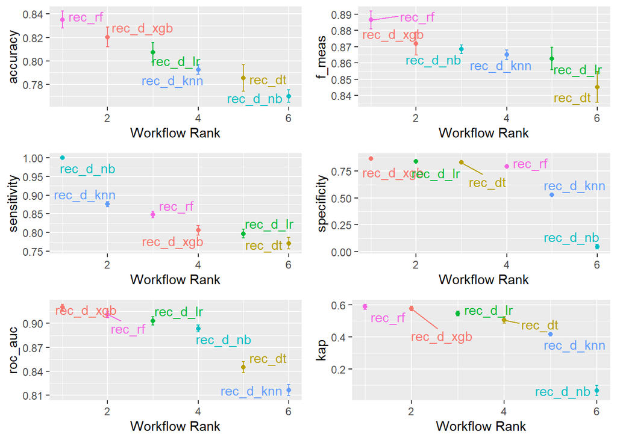

Na podstawie powyższych wyników, do dalszej analizy wybrałam algorytmy **Random Forest (rec_rf)** oraz **XGBoost (rec_d_xgb)**, które wykazały się najlepszymi wynikami.

## 4.6 Tuning modeli

```r
rf_spec <- rand_forest(mtry = tune(), min_n = tune(), trees = 500) %>%
  set_engine("ranger") %>%
  set_mode("classification")

#mtry - Liczba predyktorów losowo wybieranych przy każdym podziale drzewa.
#min_n - Minimalna liczba obserwacji w liściu drzewa.
#trees - Liczba drzew w lesie.


xgb_spec <- boost_tree(tree_depth = tune(), #Maksymalna głębokość drzewa
                       learn_rate = tune(), #Szybkość uczenia
                       loss_reduction = tune(), #Minimalna poprawa wymagana do dalszego podziału
                       min_n = tune(), #Minimalna liczba obserwacji w liściu
                       sample_size = tune(), #Proporcja obserwacji używana do trenowania każdego drzewa
                       trees = tune()) %>% #Liczba drzew
  set_engine("xgboost") %>%
  set_mode("classification")
```

### 4.6.1 Tuning Random Forest

Tworzymy zestaw parametrów do strojenia modelu lasu losowego (`rf_spec`) — ustalamy zakresy dla dwóch ważnych hiperparametrów:

- `mtry` (liczba zmiennych losowo wybieranych przy podziale drzewa),
- `min_n` (minimalna liczba obserwacji w węźle, poniżej której węzeł nie jest dzielony).

Kolejnym krokiem jest zdefiniowanie *workflow*, czyli połączenia modelu lasu losowego z przetwarzaniem danych (receptą `rec`), co umożliwia łatwą integrację procesu trenowania.

Zakomentowany fragment kodu pokazuje, jak można przeprowadzić strojenie hiperparametrów za pomocą walidacji krzyżowej (`tune_grid`), wykorzystując siatkę parametrów oraz metryki oceny modelu.

Na końcu wyniki tuningu zapisujemy do pliku RDS, aby móc je później wykorzystać bez konieczności ponownego trenowania.

```r
rf_param <- extract_parameter_set_dials(rf_spec)

rf_param <-
   rf_spec %>%
   extract_parameter_set_dials() %>%
   update(
     mtry = mtry(c(1, 10)),
     min_n = min_n(c(2,60)))
rf_param %>% extract_parameter_dials("mtry")
rf_param %>% extract_parameter_dials("min_n")


rf_wflow <- workflow() %>%
  add_model(rf_spec) %>%
  add_recipe(rec)

#set.seed(2025)
#rf_reg_tune <- rf_wflow %>%
#  tune_grid(
#    cv_folds,
#    grid = rf_param %>% grid_regular(levels = 5),
#    metrics = metryki
#  )
#saveRDS(rf_reg_tune, "rf_reg_tune.rds")
```

[figure not shown]

#### 4.6.1.1 Finalizowanie modelu

Na podstawie wyników strojenia wybieramy najlepsze parametry modelu lasu losowego, korzystając z metryki **ROC AUC**.

```r
select_best(rf_reg_tune, metric = "roc_auc")
```

```
# A tibble: 1 × 3
   mtry min_n .config
  <int> <int> <chr>
1     4    60 Preprocessor1_Model22
```

Następnie tworzymy nowy *workflow*, który finalizuje *workflow*.

```r
rf_best_param <- tibble(
  mtry = 4,
  min_n = 60)

final_rf_wflow <- rf_wflow %>%
  finalize_workflow(rf_best_param)
final_rf_wflow
```

```
══ Workflow ════════════════════════════════════════════════════════════════════
Preprocessor: Recipe
Model: rand_forest()

── Preprocessor ────────────────────────────────────────────────────────────────
1 Recipe Step

• step_upsample()

── Model ───────────────────────────────────────────────────────────────────────
Random Forest Model Specification (classification)

Main Arguments:
  mtry = 4
  trees = 500
  min_n = 60

Computational engine: ranger
```

Dopasowujemy ostateczny model do całego zbioru treningowego, przygotowując go do predykcji na zbiorze testowym.

```r
final_rf_fit <-
  final_rf_wflow %>%
  fit(train)
```

#### 4.6.1.2 Predykcja na zbiorze testowym

Metryki modelu Random Forest

| Miara | Wartość |
| --- | --- |
| Dokładność (Accuracy) | 0.837 |
| F1-score | 0.887 |
| Czułość (Sensitivity) | 0.842 |
| Specyficzność (Specificity) | 0.822 |
| ROC AUC | 0.919 |
| Kappa | 0.599 |

#### 4.6.1.3 Confusion Matrix

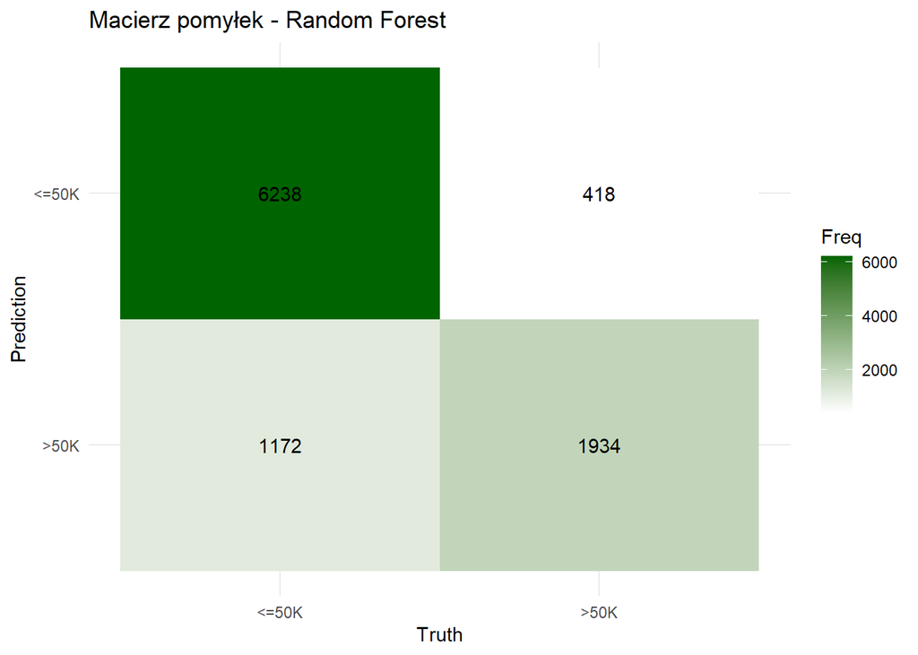

### 4.6.2 Tuning XGBoost

Definiujemy zakresy hiperparametrów **XGBoost** i tworzymy workflow z modelem oraz przepisem na dane.

Następnie generujemy siatkę parametrów do strojenia metodą *Latin Hypercube* (hipersześciany łacińskie).

Wyniki strojenia ponownie zapisujemy do pliku, aby nie trzeba było powtarzać tego czasochłonnego procesu jeszcze raz.

```r
xgb_param <- extract_parameter_set_dials(xgb_spec)

xgb_param <-
   xgb_spec %>%
   extract_parameter_set_dials() %>%
   update(
    tree_depth = tree_depth(c(3L, 10L)),
    learn_rate = learn_rate(range = c(-2, -0.5)),
    loss_reduction = loss_reduction(range = c(-5, 1)),
    min_n = min_n(c(5L, 60L)),
    sample_size = sample_prop(c(0.5, 1)),
    trees = trees(c(100L, 800L))
  )
xgb_param %>% extract_parameter_dials("tree_depth")
xgb_param %>% extract_parameter_dials("learn_rate")
xgb_param %>% extract_parameter_dials("loss_reduction")
xgb_param %>% extract_parameter_dials("min_n")
xgb_param %>% extract_parameter_dials("sample_size")
xgb_param %>% extract_parameter_dials("trees")

#grid_regular(xgb_param, levels = 2)


xgb_wflow <- workflow() %>%
  add_model(xgb_spec) %>%
  add_recipe(rec_dummy)

xgb_grid <- grid_latin_hypercube(xgb_param, size = 10) #grid_max_entropy(xgb_param, size = 20)

#cl <- makePSOCKcluster(4)
#registerDoParallel(cl)

#set.seed(2025)
#xgb_reg_tune <- xgb_wflow %>%
#  tune_grid(
#    cv_folds,
#    grid = xgb_grid,
#    metrics = metryki
#  )
#saveRDS(xgb_reg_tune, "xgb_reg_tune.rds")
#stopCluster(cl)
```

#### 4.6.2.1 Finalizowanie modelu

Na podstawie wyników strojenia wybieramy najlepsze parametry modelu.

```r
select_best(xgb_reg_tune, metric = "roc_auc")
```

```
# A tibble: 1 × 7
  trees min_n tree_depth learn_rate loss_reduction sample_size .config
  <int> <int>      <int>      <dbl>          <dbl>       <dbl> <chr>
1   631    16          6      0.111           8.53       0.921 Preprocessor1_Mo…
```

Tworzymy nowy workflow finalizujący.

```r
best_params <- select_best(xgb_reg_tune, metric = "roc_auc")

final_xgb_wflow <- xgb_wflow %>%
  finalize_workflow(best_params)
```

Dopasowujemy ostateczny model do całego zbioru treningowego.

```r
final_xgb_fit <-
  final_xgb_wflow %>%
  fit(train)
```

#### 4.6.2.2 Predykcja na zbiorze testowym

Metryki modelu XGBoost

| Miara | Wartość |
| --- | --- |
| Dokładność (Accuracy) | 0.835 |
| F1-score | 0.884 |
| Czułość (Sensitivity) | 0.824 |
| Specyficzność (Specificity) | 0.871 |
| ROC AUC | 0.931 |
| Kappa | 0.607 |

#### 4.6.2.3 Confusion matrix

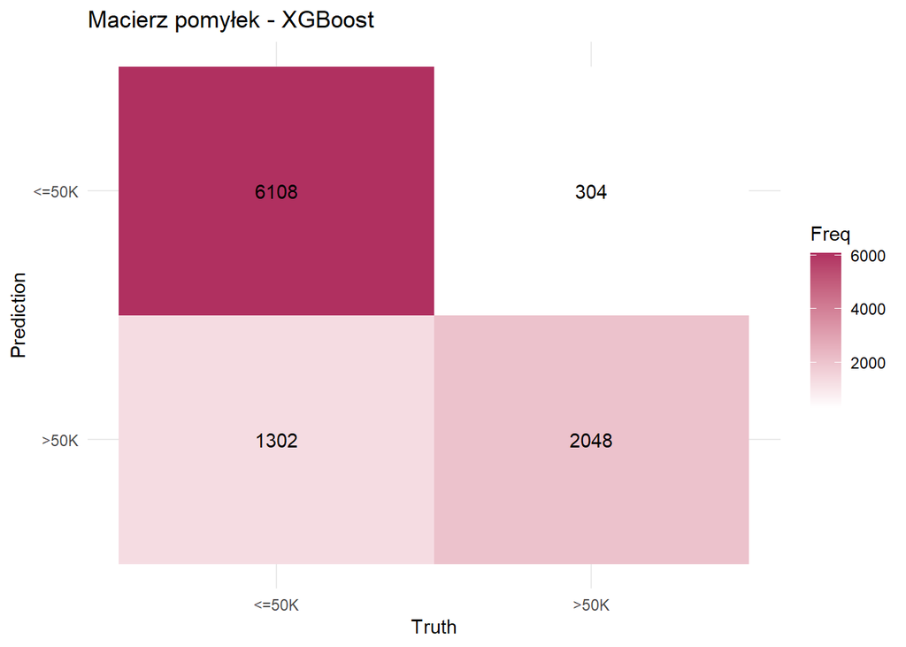

# 5 Podsumowanie

Przeprowadzona została analiza zbioru mająca na celu przewidzenie, czy dana osoba zarabia powyżej czy poniżej 50 tysięcy dolarów rocznie.

Z uwagi na **niezbalansowany** zbiór danych (więcej obserwacji klasy <=50K), zastosowano *oversampling*, aby poprawić jakość predykcji i zrównoważyć klasy.

Zbudowane zostały, a następnie porównane modele klasyfikacyjne: **regresja logistyczna**, model **drzewa decyzyjnego**, **las losowy**, **naiwny klasyfikator bayesowski**, **XGBoost** oraz algorytm **k-najbliższych sąsiadów**. Spośród nich najwyższe wyniki osiągnęły modele **Random Forest** i **XGBoost**, które zostały następnie stuningowane przy użyciu **walidacji krzyżowej** i **przeszukiwania siatki** parametrów.

Ostatecznie, oba modele osiągnęły dość dobre wyniki. Jednak mimo to nie idealnie radzą sobie z klasyfikacją i mają tendencję do błędnej klasyfikacji osób zarabiających <=50 jako osób które zarazabiają > 50K.

# 6 Bibliografia

- https://dax44.github.io/ModelsValidation/
- https://pl.wikipedia.org/wiki/Wikipedia:Strona_g%C5%82%C3%B3wna
- Wiedza teoretyczna i praktyczna zdobyta podczas wykładów i laboratoriów z przedmiotu *Metody walidacji modeli statystycznych.*